# Rain Movies

Matthew Ross

11/7/2019

# Using R to make movies

While most of the visualizations made in R are `static`, with a single image displaying the data, one can also make videos in R. These are particularly useful when data has a temporal component or a third axis for display. Here we will show a few ways to make videos using R and airport weather data

# Data acquisition and reshaping

## Finding our station names

```r
#riem_networks() # look for network names
co_stations <- riem_stations(network = 'CO_ASOS')
#View(co_stations)
stations <- c('AFF', 'FNL')
```

## Download station data

```r
af_p <- riem_measures(station='AFF',date_start = '2018-10-01',
                      date_end = '2019-09-30')
fc <- riem_measures(station='FNL',date_start = '2018-10-01',
                      date_end = '2019-09-30')
View(fc)
```

## Convert both to daily

```r
daily_p <- fc %>%
  bind_rows(af_p) %>%
  mutate(date = as.Date(valid)) %>%
  group_by(date, station, lon, lat) %>%
  summarize(mean_temp = mean(tmpf,na.rm=T),
            min_temp = min(tmpf,na.rm=T),
            max_temp = max(tmpf,na.rm=T),
            daily_p = sum(p01i,na.rm=T)) %>%
  as.data.frame() %>%
  as_tibble()
```

# Making videos

## Boring first video

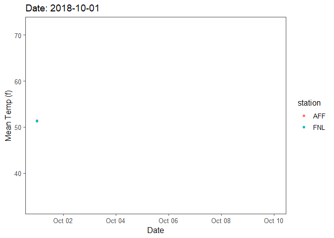

```r
slice_p <- daily_p %>%
  slice(1:20)
p1 <- ggplot(slice_p,aes(x=date,y=mean_temp,color=station,group=station)) +
  geom_point() +
  labs(title = 'Date: {frame_time}', x='Date',y= 'Mean Temp (f)') +
  transition_time(date)
animate(p1, nframes=nrow(slice_p))
```

## Leaving a trace

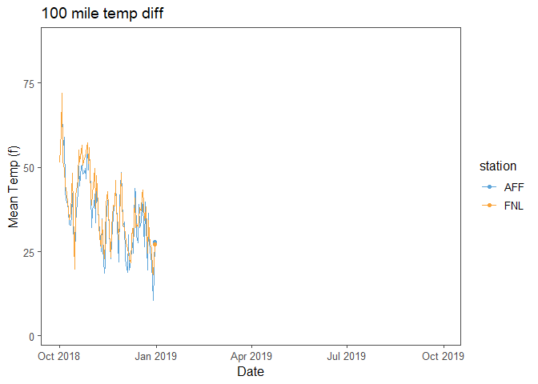

```r
p2 <- ggplot(daily_p,aes(x=date,y=mean_temp,color=station,group=station)) +
  geom_line() +
  geom_point() +
  labs(title = '100 mile temp diff', x='Date',y= 'Mean Temp (f)') +
  transition_reveal(date) +
  scale_color_few()
animate(p2, nframes=3)
```

## Static background plot

```r
usa <- us_states()
co <- usa %>%
  filter(name == 'Colorado')
sf_p <- daily_p %>%
  st_as_sf(coords=c('lon','lat'),crs=4326)
co_elev <- elevatr::get_elev_raster(co,z=6)
```

```
## Merging DEMs
```

```
## Reprojecting DEM to original projection
```

```
## Note: Elevation units are in meters.
## Note: The coordinate reference system is:
##  +proj=longlat +datum=WGS84 +no_defs +ellps=WGS84 +towgs84=0,0,0
```

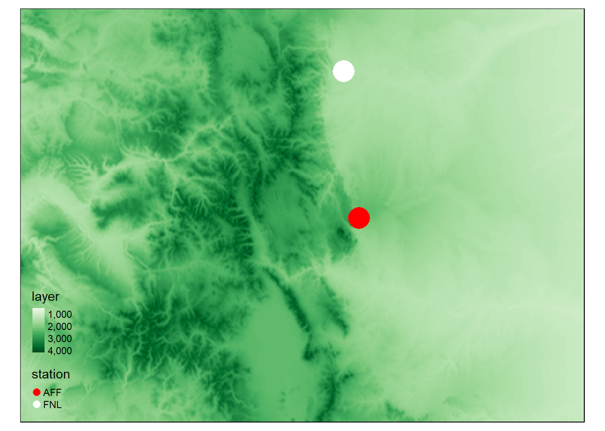

```r
tm_shape(co) +
  tm_polygons() +
  tm_shape(co_elev) +
  tm_raster(style='cont',palette = 'Greens') +
  tm_shape(sf_p) +
  tm_dots(col='station',size=3,palette=c('red','white'))
```

## Quick plot

```r
basemap <- tm_shape(co) +
    tm_polygons() +
  tm_shape(co_elev) +
    tm_raster(style='cont',
              palette = 'Greens',
              title='Elevation (m)')
```

```r
full_dates <- unique(sf_p$date)
sequence <- 1:length(full_dates)
saveGIF({
  for(i in sequence){
  sub_sf <- sf_p %>%
    filter(date == full_dates[i]) %>%
    filter(daily_p > 0)

  if(nrow(sub_sf) > 0){
  finalmap <- basemap + tm_shape(sub_sf) +
    tm_dots(col='station',
            size=2,
            palette = c('red','white'),
            legend.show = F)
  }else{finalmap <- basemap}
  print(finalmap +
          tm_layout(title=full_dates[i]) +
          tm_add_legend(type='symbol',
                        labels=c('Air Force',
                                 'Fort Collins'),
                        col=c('red','white'),
                        title='Station'))
  }
},movie.name = 'precip_flash.gif',
  interval=0.05,
  ani.width=1000,
  ani.height=800)
```

# A cooler video

## Let’s see if we can see weather fronts by downloading all Colorado data and

trying to get those to flash

```r
all_co <- map(co_stations$id,~riem_measures(.x,date_start='2018-10-01',
                                         date_end = '2019-09-30'))
stack_co <- do.call('rbind',all_co)
daily_p <- stack_co %>%
  mutate(date = as.Date(valid)) %>%
  group_by(date, station, lon, lat) %>%
  summarize(mean_temp = mean(tmpf,na.rm=T),
            min_temp = min(tmpf,na.rm=T),
            max_temp = max(tmpf,na.rm=T),
            daily_p = sum(p01i,na.rm=T)) %>%
  as.data.frame() %>%
  as_tibble()
save(daily_p,file='DailyP.RData')
```

## Full state video

This code is almost identical to the above, but it uses all ASOS/AWOS precip stations

```r
load('DailyP.RData')
daily_sf <- daily_p %>%
  st_as_sf(.,coords=c('lon','lat'),crs=4326,remove=F)
full_dates <- unique(daily_sf$date)
sequence <- 1:length(full_dates)
saveGIF({
  for(i in sequence){
  sub_sf <- daily_sf %>%
    filter(date == full_dates[i]) %>%
    filter(daily_p > 0)

  if(nrow(sub_sf) > 0){
  finalmap <- basemap + tm_shape(sub_sf) +
    tm_dots(title.size='Daily Precip (in)',
            col='lon',
            size='daily_p',
            style='cont',
            palette='Oranges',
            legend.show = F,
            size.max=19,
            scale=3.5,
            sizes.legend=c(0,1,5,10,20))
  }else{finalmap <- basemap}
  print(finalmap +
          tm_layout(title=full_dates[i],
        legend.position=c(0.7,0.2)))
  }
},movie.name = 'precip_flash_all.gif',
  interval=0.12,
  ani.width=1000,
  ani.height=800)
```

# In Class work.

## GGanimate

Make a video showing the correlation between Air Force Academy and Fort Collins between the min, mean, and max temps. The movie should cover the full year.

```r
temperature_data_long <- daily_p %>%
  select(-c(daily_p,lon,lat)) %>%
  gather(key = "temp_type", value = "value", -c(date,station))

p3 <- ggplot(temperature_data_long,aes(x=date,y=value,color=station)) +
  geom_line() +
  geom_point() +
  labs(title = 'Temperature Variation Across Airports', x='Date',y= 'Temperature (F)') +
  facet_wrap(~temp_type) +
  transition_reveal(date) +
  scale_color_few() +
  view_follow(fixed_x = FALSE, fixed_y = FALSE, exclude_layer = NULL,
              aspect_ratio = 1)
animate(p3, nframes=nrow(temperature_data_long))
```

## (Animation package)

Make a video of mean temperature differences for the full Colorado dataset (you need to download this [here](https://www.dropbox.com/s/s7zt18elgoh8q2b/DailyP.RData?dl=0)) first.

The video should look similar to the one above, but I want you to choose your own style (change the background, add other layers (like counties or cities)), etc…

```r
load('DailyP.RData')

basemap_kw <- tm_shape(co) +
    tm_polygons() +
  tm_shape(co_elev) +
    tm_raster(style='cont',
              palette = 'Blues',
              title='Elevation (m)')

daily_sf <- daily_p %>%
  st_as_sf(.,coords=c('lon','lat'),crs=4326,remove=F)
full_dates <- unique(daily_sf$date)
sequence <- length(50) #Speed it up
saveGIF({
  for(i in sequence){
  sub_sf <- daily_sf %>%
    filter(date == full_dates[i])

  if(nrow(sub_sf) > 0){
  finalmap <- basemap_kw + tm_shape(sub_sf) +
    tm_dots(title.size='Daily Mean Temperature (F)',
            col='mean_temp',
            style='cont',
            palette='Oranges',
            legend.show = F,
            size.max=19,
            scale=15.5,
            sizes.legend=c(0,1,5,10,20))
  }else{finalmap <- basemap_kw}
  print(finalmap +
          tm_layout(title=full_dates[i],
        legend.position=c(0.8,0.1)))
  }
},movie.namey = 'temp_flash_all.gif',
  interval=0.50,
  ani.width=1000,
  ani.height=800)
```